# Data Analysis Homework 2

Artin Tajdini 95109983

February 18, 2018

# سؤال ۱

ابتدا بر اساس کمپانی گروه می کنیم و تعداد هرکدام را در یک متغیر میریزیم و براساس این متغیر مرتب می کنیم و ۲۰ تای اول را ذخیره می کنیم

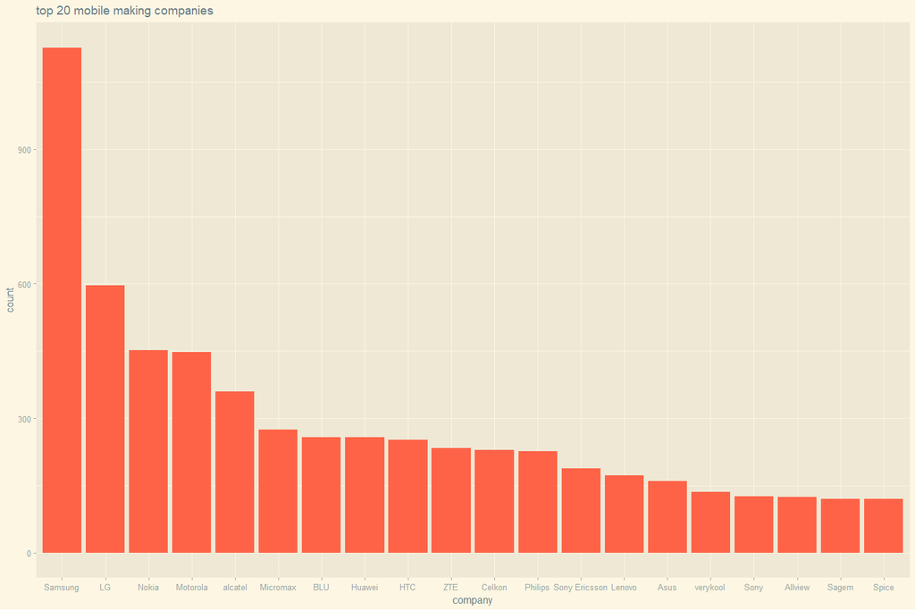

```r
mobile %>%
  group_by(company) %>%
  summarise(count = n()) %>%
  arrange(desc(count) ) %>%
  top_n(20) -> p1

p1$company = factor(p1$company, levels = p1$company)
ggplot(data = p1, aes(x = company, y = count)) +
  geom_bar(fill = "tomato", stat = "identity") +
  ggtitle("top 20 mobile making companies") +
  theme_solarized_2()
```

# سؤال ۲

چون سال ها گسسته اند پس ممکن است چند نقطه در نمودار روی هم بیفتد که با استفاده از geom_count نمایش این نقاط بهتر میشود

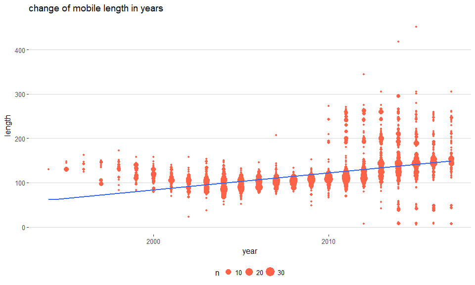

```r
ggplot(data = mobile, aes(x = year, y = dim_length)) +
  theme_hc() + geom_count(col = "tomato") +
  geom_smooth(method = "lm", se = F) +
  ggtitle("change of mobile length in years") +
  xlab("year") +
  ylab("length")
```

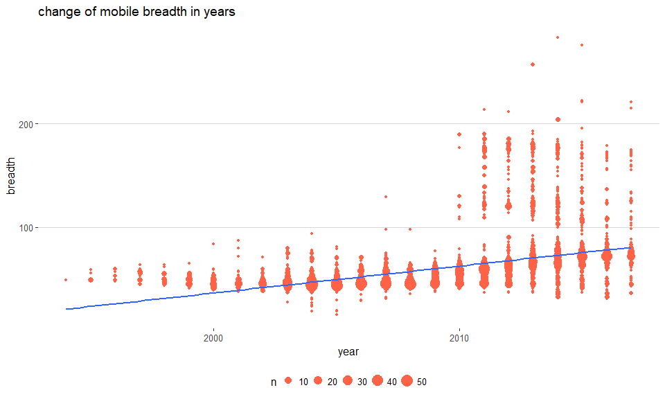

```r
ggplot(data = mobile, aes(x = year, y = dim_breadth)) +
  theme_hc() + geom_count(col = "tomato") +
  geom_smooth(method = "lm", se = F) +
  ggtitle("change of mobile breadth in years") +
  xlab("year") +
  ylab("breadth")
```

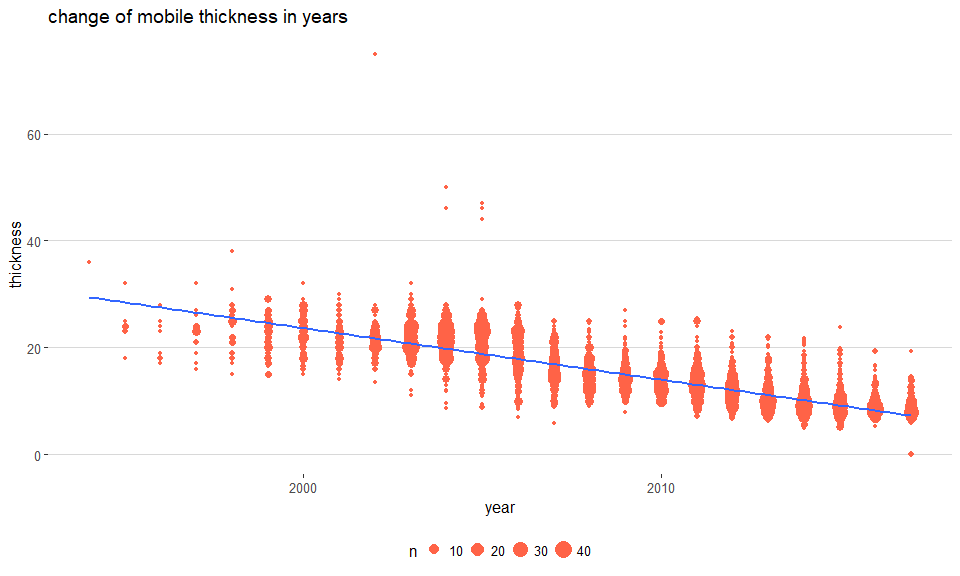

```r
ggplot(data = mobile, aes(x = year, y = dim_thickness)) +
  theme_hc() + geom_count(col = "tomato") +
  geom_smooth(method = "lm", se = F) +
  ggtitle("change of mobile thickness in years") +
  xlab("year") +
  ylab("thickness")
```

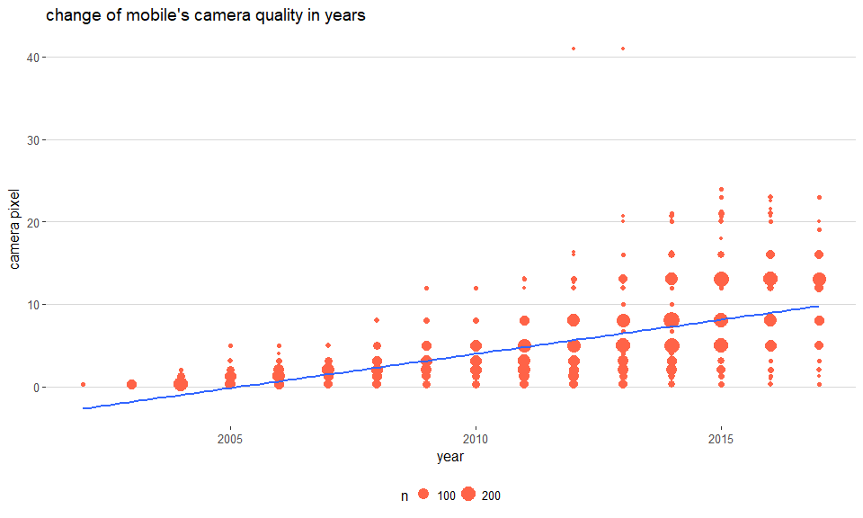

```r
ggplot(data = mobile, aes(x = year, y = cam_px)) +
  theme_hc() + geom_count(col = "tomato") +
  geom_smooth(method = "lm", se = F) +
  ggtitle("change of mobile's camera quality in years") +
  xlab("year") +
  ylab("camera pixel")
```

# سؤال ۳

برحسب LTE و تعداد سیم کارت گروه بندی میکنیم و میانگین قیمت هرکدام را حساب می کنیم

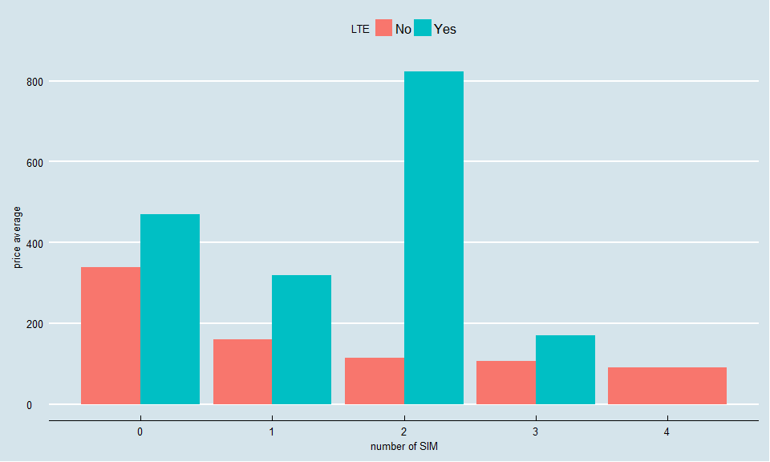

```r
mobile %>%
  group_by(sim_no, LTE) %>%
  summarise(avrprice = mean(price, na.rm = T)) -> d3

ggplot(data = d3, aes(x = sim_no, y = avrprice, fill = LTE)) + theme_economist() +
  geom_bar(stat = "identity", position = "dodge") +
  xlab("number of SIM") + ylab("price average")
```

# سؤال ۴

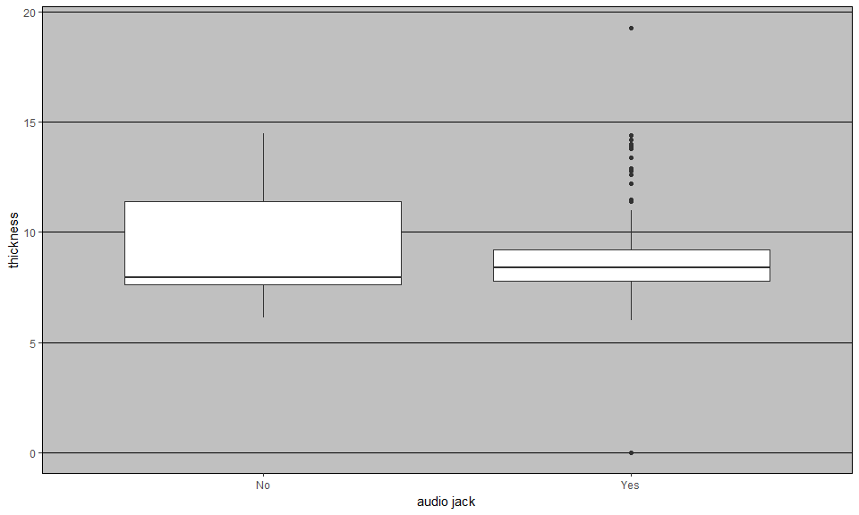

```r
ggplot(data = filter(mobile, year == 2017), aes(x = audio_jack, y = dim_thickness)) +
  geom_boxplot(na.rm = T) + theme_excel() +
    xlab("audio jack") + ylab("thickness")
```

# سؤال ۵

ppi یعنی تراکم پیکسل در یک اینچ مربع

ابتدا با استفاده از aspect طول و عرض صفحه نمایش را حساب می کنیم. سپس با تقسیم تعداد پیکسل ها بر طول و عرض و رادیکال گرفتن ppi را حساب می کنیم.

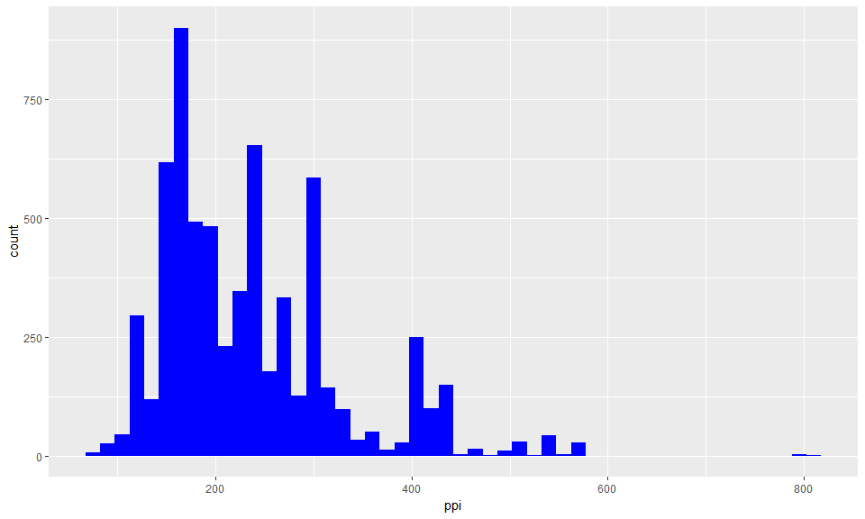

```r
mobile$scr_row = (mobile$display_size^2 / (mobile$aspect_col^2 + mobile$aspect_row^2) * mobile$aspect_col^2)^0.5
mobile$scr_col = (mobile$display_size^2 / (mobile$aspect_col^2 + mobile$aspect_row^2) * mobile$aspect_row^2)^0.5

mobile$ppi = (mobile$px_col * mobile$px_row / (mobile$scr_col * mobile$scr_row))^0.5

ggplot(data = mobile, aes(x = ppi)) + geom_histogram(binwidth = 15, na.rm = T, fill = "blue")
```

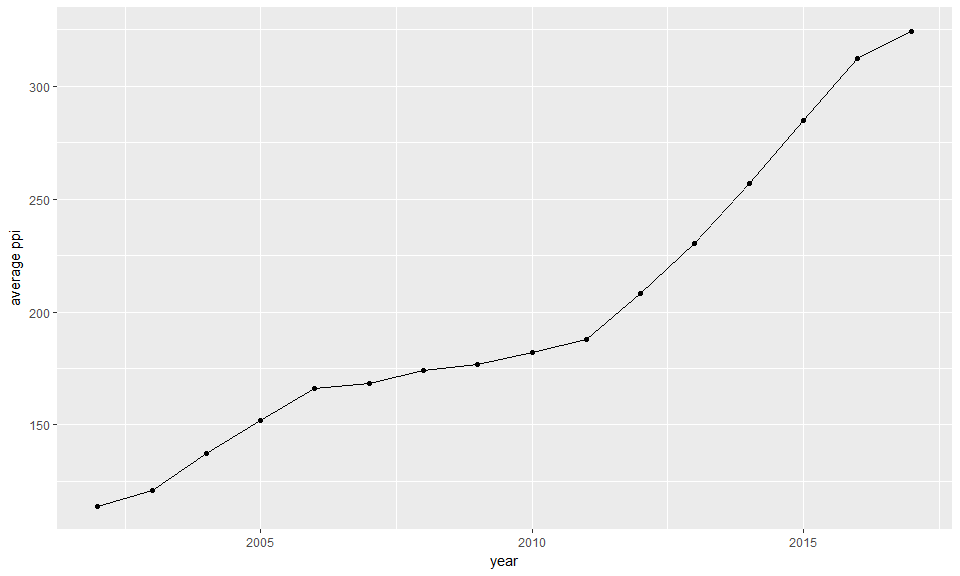

```r
mobile %>%
  filter(!is.na(ppi)) %>%
  group_by(year) %>%
  summarise(avrppi = mean(ppi, na.rm = T)) -> d5

ggplot(data = d5, aes(x = year, y = avrppi)) + geom_point() + geom_line() + ylab("average ppi")
```

```r
mobile[ which.max(mobile$ppi), ] %>%
  select(company, device, price, ppi)
```

```
# A tibble: 1 x 4
  company device            price   ppi
  <chr>   <chr>             <int> <dbl>
1 Sony    Xperia XZ Premium   660   807
```

# سؤال ۶

گوشکوبیت یک گوشی یعنی یک گوشی ای که چگالی نسبتا بالا و ضخامت بالا دارد. همچنین چون این گوشی ها قدیمی اند صفحه نمایششان کوچک است. تبلت ها و ساعت ها را نیز حذف می کنیم.

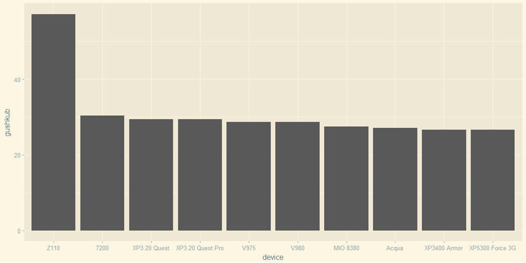

```r
mobile %>%
  filter(dim_length <= 150 & dim_length >= 50) %>%
  mutate(gushkub = weight * dim_thickness / (dim_breadth^0.5 * dim_length^0.5 * display_size)) %>%
  arrange( desc( gushkub )) %>%
  slice(1:10) %>%
  ggplot(aes(x = reorder(device, -gushkub), y = gushkub)) + geom_bar(stat = "identity") + theme_solarized_2() +
  xlab("device")
```

# سؤال ۷

برای اینکه گوشی در آب غرق نشود باید چگالی اش از آب کمتر باشد پس چگالی گوشی ها را حساب می کنیم و هیستوگرام آنهایی باشان کمتر از یک است را می کشیم و با یک خط از بقیه جدا می کنیم (بر حسب گرم بر سانتی متر مکعب)

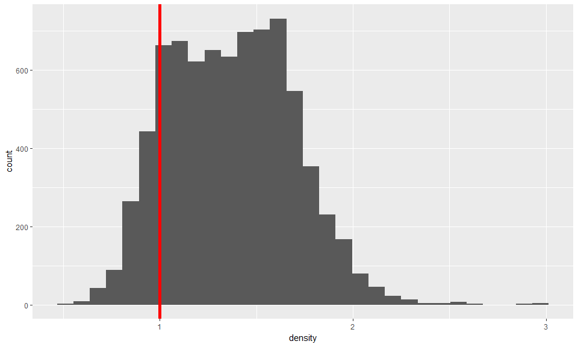

```r
mobile %>%
  filter(weight / (dim_length * dim_breadth * dim_thickness * 1e-3) <= 3) %>%
  ggplot(., aes( x = weight / (dim_length * dim_breadth * dim_thickness * 1e-3))) +
  xlab("density") +
  geom_histogram() + geom_vline(xintercept = 1, col = "red", size = 2)
```

# سؤال ۸

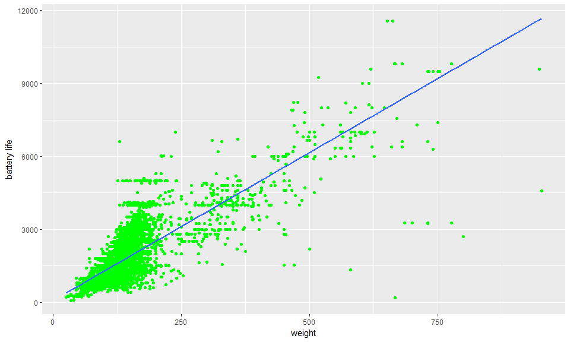

```r
ggplot(mobile[ which( !is.na(mobile$weight) & !is.na(mobile$battery_mah) ),],
       aes(x = weight, y = battery_mah)) +
  geom_point(col = "green") +
  geom_smooth(method = "lm", se = F) +
  ylab("battery life")
```

```r
cor(mobile$weight, mobile$battery_mah, use = "complete.obs")
```

```
[1] 0.8086273
```

# سؤال ۹

ابتدا تبلت ها و ساعت ها را حذف می کنیم سپس پرچم دار یعنی گرانترین گوشی درهر سال را در میاوریم

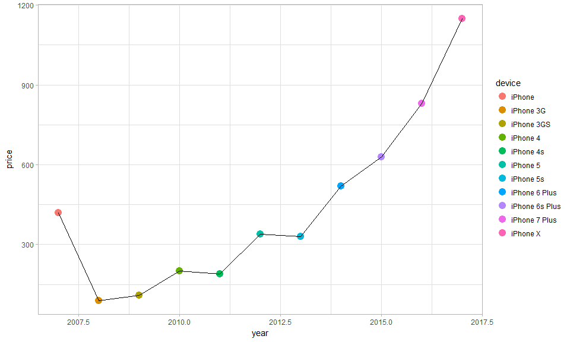

```r
mobile %>%
  filter(company == "Apple" & dim_length <= 160 & dim_length >= 50) %>%
  group_by(year) %>%
  filter(price >= max(price, na.rm = T) ) %>%
  ggplot(., aes(x = year, y = price, col = device)) + geom_point(size = 4) + geom_line(col = "black") + theme_light()
```

# سؤال ۱۰

## میانگین قیمت گوشی ها برحسب سال

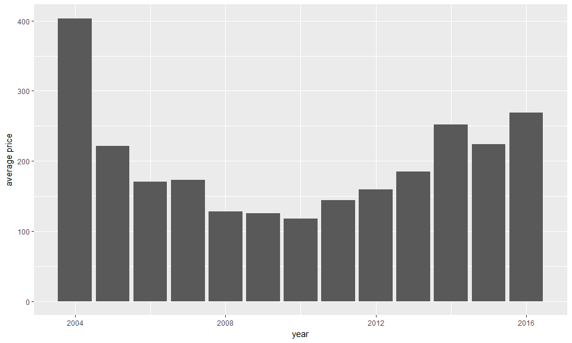

```r
mobile %>%
  filter(year < 2017, year > 2003) %>%
  group_by(year) %>%
  summarise(s = mean(price, na.rm = T)) %>%
  ggplot(aes(x = year, y = s)) + geom_bar(stat = "identity") + ylab("average price")
```

## لاغر شدن گوشی ها در گذر زمان!

نمودار طول موبایل نسبت به ضخامت آن دربازه زمانی ۱۹۹۸ تا ۲۰۰۵ (جز ۲۰۰۲ که دیتایش اشتباه بود) در میابیم که ابتدا گوشی های با طول بیشتر ضخامت بیشتری داشتند اما به مرور زمان کورلیشنشان منفی می شود و گوشی های بلند تر ضخامت کمتری دارند

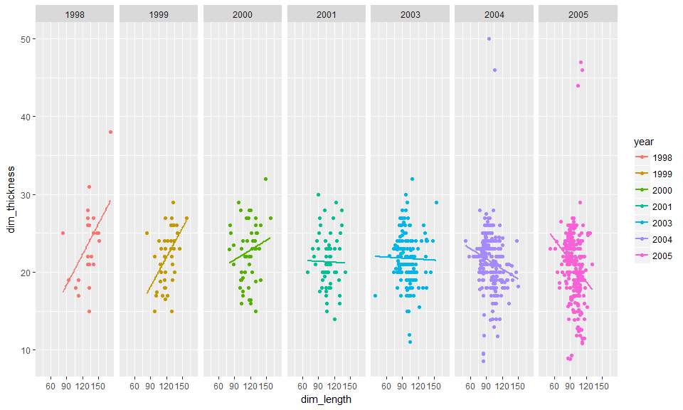

```r
mobile$year = as.character(mobile$year)
mobile %>%
  filter(year <= 2005 & year >= 1998 & year != 2002) %>%
  ggplot(aes(x = dim_length, y = dim_thickness, col = year)) + geom_point() + geom_smooth(aes(group = year), method = "lm", se = F) + facet_grid(~year)
```

## درصد احاطه سیستم عامل ها به بازار در طول زمان

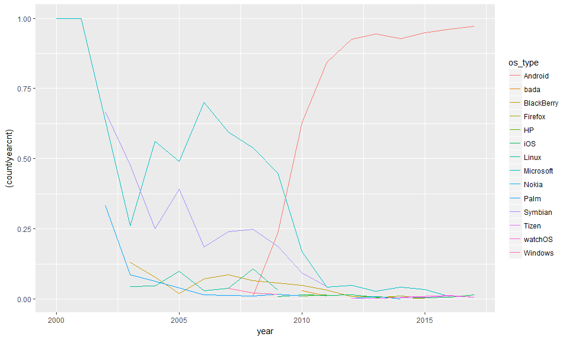

```r
mobile$year = as.integer(mobile$year)

mobile %>%
  filter(!is.na(os_type) & !is.na(year) & os_type != "other") %>%
  group_by(os_type, year) %>%
  summarise(count = n()) %>%
  select(os_type, year, count) -> cm

cm %>%
  group_by(year) %>%
  summarise(yearcnt = sum(count)) -> cym

cc = full_join(cm, cym)

ggplot(cc, aes(x = year, y = (count / yearcnt), col = os_type)) + geom_line()
```